# Reproducible Research-Peer Assessment 1

Pablo Clar

## Loading and preprocessing the data

### Introduction

It is now possible to collect a large amount of data about personal movement using activity monitoring devices such as a Fitbit, Nike Fuelband, or Jawbone Up. These type of devices are part of the “quantified self” movement - a group of enthusiasts who take measurements about themselves regularly to improve their health, to find patterns in their behavior, or because they are tech geeks. But these data remain under-utilized both because the raw data are hard to obtain and there is a lack of statistical methods and software for processing and interpreting the data.

This assignment makes use of data from a personal activity monitoring device. This device collects data at 5 minute intervals through out the day. The data consists of two months of data from an anonymous individual collected during the months of October and November, 2012 and include the number of steps taken in 5 minute intervals each day.

The data for this assignment can be downloaded from the course web site:

Dataset: Activity monitoring data [52K]

The variables included in this dataset are:

*steps: Number of steps taking in a 5-minute interval (missing values are coded as NA)

*date: The date on which the measurement was taken in YYYY-MM-DD format

*interval: Identifier for the 5-minute interval in which measurement was taken

The dataset is stored in a comma-separated-value (CSV) file and there are a total of 17,568 observations in this dataset.

```r
library ("data.table")
URL_file <- "https://d396qusza40orc.cloudfront.net/repdata%2Fdata%2Factivity.zip"
download.file (URL_file, destfile = "./repdata.Fdata.Factivity.zip", method = "auto")
unzip ("./repdata.Fdata.Factivity.zip")
rep_research_file <- data.table::fread(input = "./activity.csv")
summary (rep_research_file)
```

```
##      steps            date              interval
##  Min.   :  0.00   Length:17568       Min.   :   0.0
##  1st Qu.:  0.00   Class :character   1st Qu.: 588.8
##  Median :  0.00   Mode  :character   Median :1177.5
##  Mean   : 37.38                      Mean   :1177.5
##  3rd Qu.: 12.00                      3rd Qu.:1766.2
##  Max.   :806.00                      Max.   :2355.0
##  NA's   :2304
```

```r
head (rep_research_file, 10)
```

```
##     steps       date interval
##  1:    NA 2012-10-01        0
##  2:    NA 2012-10-01        5
##  3:    NA 2012-10-01       10
##  4:    NA 2012-10-01       15
##  5:    NA 2012-10-01       20
##  6:    NA 2012-10-01       25
##  7:    NA 2012-10-01       30
##  8:    NA 2012-10-01       35
##  9:    NA 2012-10-01       40
## 10:    NA 2012-10-01       45
```

## What is mean total number of steps taken per day?

```r
library ("ggplot2")
Total_Steps_Day <- rep_research_file [, c(lapply(.SD, sum, na.rm = FALSE)), .SDcols = c("steps"), by = .(date)]
# show first 10 values:
head (Total_Steps_Day, 10)
```

```
##           date steps
##  1: 2012-10-01    NA
##  2: 2012-10-02   126
##  3: 2012-10-03 11352
##  4: 2012-10-04 12116
##  5: 2012-10-05 13294
##  6: 2012-10-06 15420
##  7: 2012-10-07 11015
##  8: 2012-10-08    NA
##  9: 2012-10-09 12811
## 10: 2012-10-10  9900
```

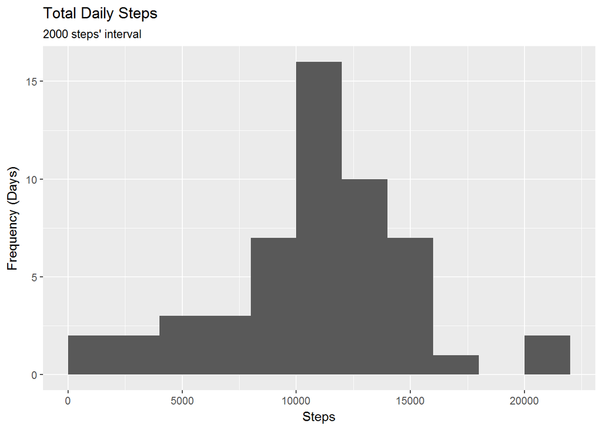

```r
# Histogram of the Total Number of Steps per day
p1 <- ggplot (Total_Steps_Day,  aes(x = steps))
p1 <- p1 + geom_histogram (binwidth = 2000, boundary = 0)
p1 <- p1 + labs (title = "Total Daily Steps", subtitle = "2000 steps' interval", x = "Steps", y = "Frequency (Days)")
print (p1)
```

```r
# Mean and Median of Total Number of Steps per Day
Mean_Steps <- mean (Total_Steps_Day [,steps], na.rm = TRUE)
Median_Steps <- median (Total_Steps_Day [,steps], na.rm = TRUE)
# Mean
print (Mean_Steps, digits = 1)
```

```
## [1] 10766
```

```r
#Median
print (Median_Steps, digits = 1)
```

```
## [1] 10765
```

## What is the average daily activity pattern?

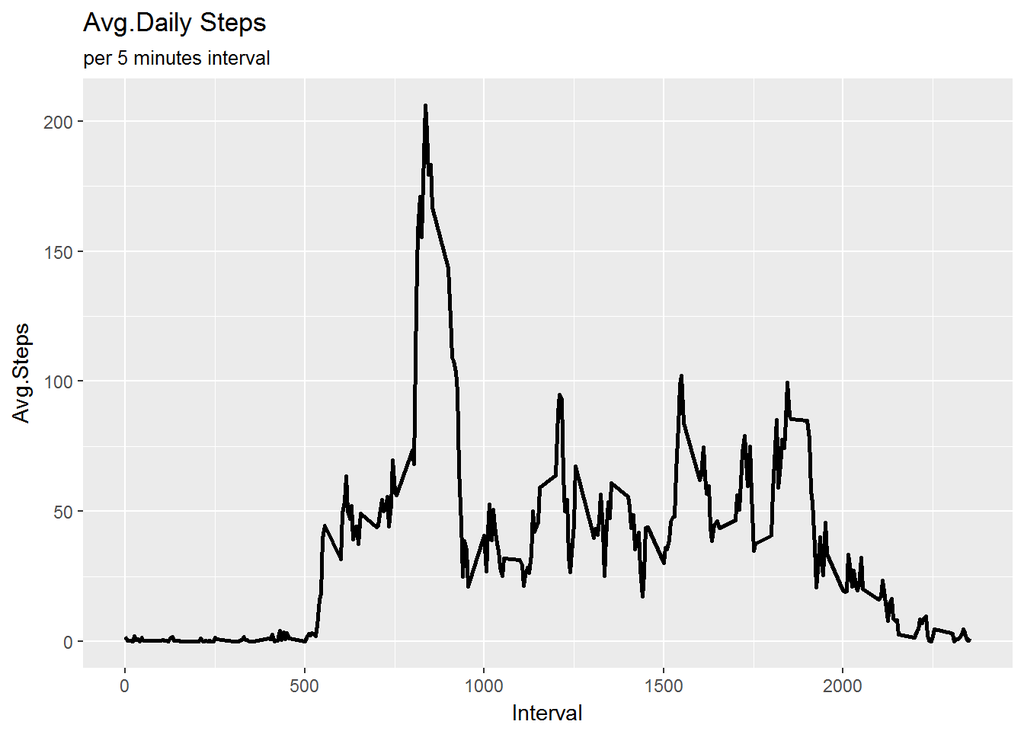

```r
# Average daily activity pattern (average of steps in each interval across days)
Avg_Steps_Int <- rep_research_file [, c(lapply(.SD, mean, na.rm = TRUE)), .SDcols = c("steps"), by = .(interval)]
# Time Series of the avg steps per 5 minute interval
q1 <- ggplot (Avg_Steps_Int, aes (x = interval, y = steps))
q1 <- q1 + geom_line  (size = 1)
q1 <- q1 + labs (title = "Avg.Daily Steps", subtitle = "per 5 minutes interval", x = "Interval", y = "Avg.Steps")
print (q1)
```

```r
# Interval with maximum number of average steps
Max_Interval <- Avg_Steps_Int [steps == max(steps)]
print(Max_Interval, digits = 1)
```

```
##    interval steps
## 1:      835   206
```

```r
#Number of missing values in original dataset
qty_NA <- sum(is.na(rep_research_file$steps))
print (qty_NA, digits = 1)
```

```
## [1] 2304
```

## Imputing missing values

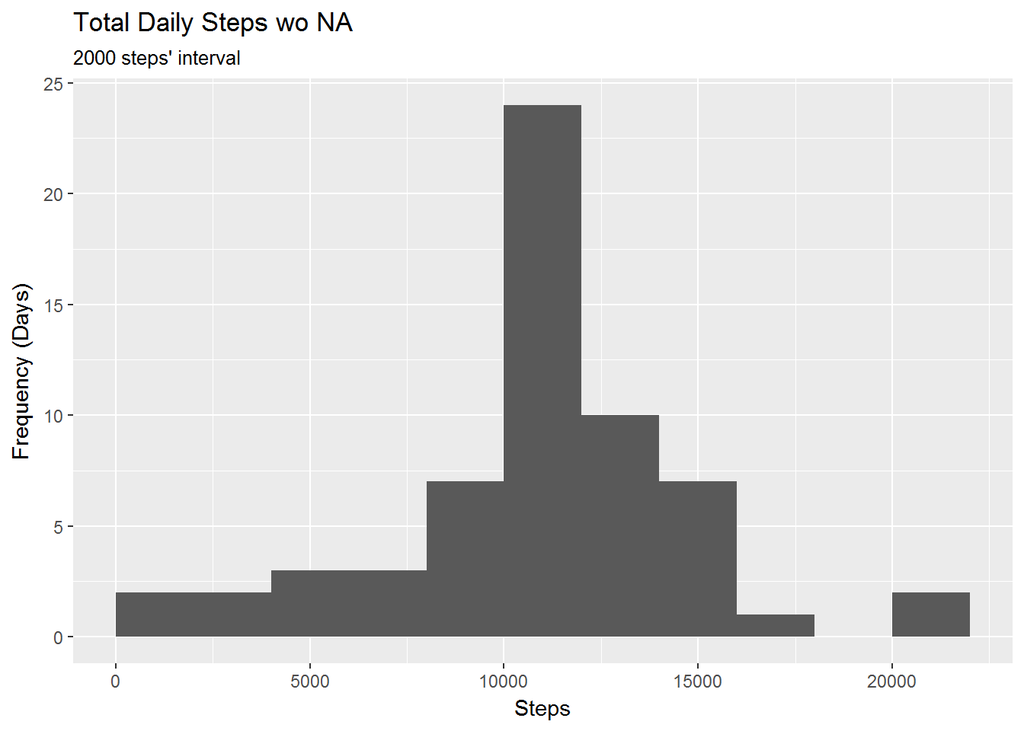

```r
#Filling missing values (NA) with average for the interval
rep_research_file <- within (rep_research_file, steps <- ifelse (is.na(steps),Avg_Steps_Int$steps,steps))
#Create new dataset with the missing data filled in
data.table::fwrite(rep_research_file, file = "./activity_cleared.csv", quote = TRUE)
# Histogram, mean and median using new file without NA
# Total steps per day, new calculation
NTotal_Steps_Day <- rep_research_file [, c(lapply(.SD, sum, na.rm = FALSE)), .SDcols = c("steps"), by = .(date)]
# Histogram of the Total Number of Steps per day
p2 <- ggplot (NTotal_Steps_Day,  aes(x = steps))
p2 <- p2 + geom_histogram (binwidth = 2000, boundary = 0)
p2 <- p2 + labs (title = "Total Daily Steps wo NA", subtitle = "2000 steps' interval", x = "Steps", y = "Frequency (Days)")
print (p2)
```

```r
# Mean and Median of Total Number of Steps per Day
NMean_Steps <- mean (NTotal_Steps_Day [,steps], na.rm = TRUE)
NMedian_Steps <- median (NTotal_Steps_Day [,steps], na.rm = TRUE)
print (NMean_Steps, digits = 1)
```

```
## [1] 10766
```

```r
print (NMedian_Steps, digits = 1)
```

```
## [1] 10766
```

## Are there differences in activity patterns between weekdays and weekends?

```r
library ("plyr")
library("gridExtra", lib.loc="~/R/R-3.4.0/library")
```

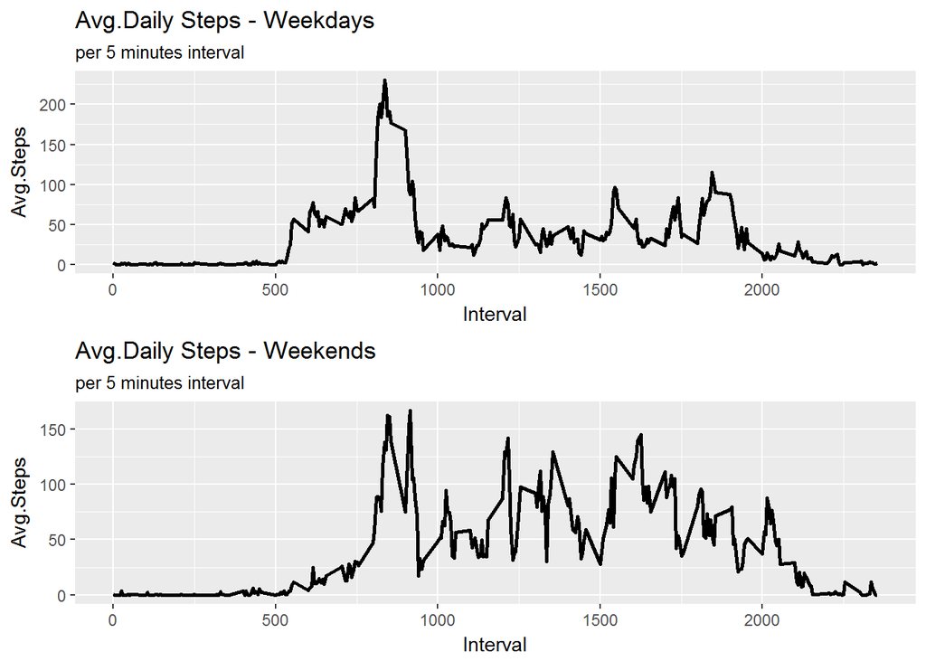

```r
# Activity pattern differs between weekdays and weekend?
# First we need to identify weekdays/weekends and for that we need to adjust date format
rep_research_file$date <- as.Date (rep_research_file$date)
# Now we identify weekday/weekend
rep_research_file <- rep_research_file [, 'WEEKDAY' := weekdays(x = date)]
rep_research_file$WEEKDAY <- revalue(rep_research_file$WEEKDAY,c("Monday"="YES","Tuesday"="YES","Wednesday"="YES","Thursday"="YES","Friday"="YES"))
rep_research_file$WEEKDAY <- revalue(rep_research_file$WEEKDAY,c("Saturday"="NO","Sunday"="NO"))
# We calculate the average steps per interval in weeekdays and weekends to graphic with then
WD_Avg_Steps_Int <- rep_research_file [WEEKDAY == 'YES', c(lapply(.SD, mean, na.rm = TRUE)), .SDcols = c("steps"), by = .(interval)]
WE_Avg_Steps_Int <- rep_research_file [WEEKDAY == 'NO', c(lapply(.SD, mean, na.rm = TRUE)), .SDcols = c("steps"), by = .(interval)]
# Graphic comparison
q3 <- ggplot (WD_Avg_Steps_Int, aes (x = interval, y = steps))
q3 <- q3 + geom_line  (size = 1)
q3 <- q3 + labs (title = "Avg.Daily Steps - Weekdays", subtitle = "per 5 minutes interval", x = "Interval", y = "Avg.Steps")
q4 <- ggplot (WE_Avg_Steps_Int, aes (x = interval, y = steps))
q4 <- q4 + geom_line  (size = 1)
q4 <- q4 + labs (title = "Avg.Daily Steps - Weekends", subtitle = "per 5 minutes interval", x = "Interval", y = "Avg.Steps")
grid.arrange(q3, q4)
```